# TMDB_Movies_EDA

### TMDB Movies EDA

Dataset : https://www.kaggle.com/datasets/asaniczka/tmdb-movies-dataset-2023-930k-movies

##### Environment Setup & Data Loading

Importing libraries

```python
import pandas as pd
import numpy as np

import matplotlib.pyplot as plt
import seaborn as sns

import plotly.express as px
import plotly.graph_objects as go
from plotly.subplots import make_subplots

# import plotly.io as pio
# pio.renderers.default='notebook_connected'
```

Read Data from CSV

```python
data = pd.read_csv('Dataset/TMDB Movies Dataset.csv', usecols=['id', 'title', 'vote_average', 'vote_count', 'status', 'revenue', 'release_date', 'runtime', 'budget', 'overview', 'genres', 'original_language', 'production_companies', 'production_countries', 'spoken_languages', 'keywords', 'homepage', 'imdb_id', 'popularity', 'tagline'])

print("Original Data Shape : ", data.shape)
```

```
Original Data Shape :  (1376742, 20)
```

Random Sampling

```python
# data = data.sample(n=300000, random_state=42)

# print("Sampling Data Shape : ", data.shape)
```

Display first 5 records from dataset

```python
display(data.head(5))
```

|  | id | title | vote_average | vote_count | status | release_date | revenue | runtime | budget | homepage | imdb_id | original_language | overview | popularity | tagline | genres | production_companies | production_countries | spoken_languages | keywords |
| --- | --- | --- | --- | --- | --- | --- | --- | --- | --- | --- | --- | --- | --- | --- | --- | --- | --- | --- | --- | --- |
| 0 | 27205 | Inception | 8.364 | 34495 | Released | 2010-07-15 | 825532764 | 148 | 160000000 | https://www.warnerbros.com/movies/inception | tt1375666 | en | Cobb, a skilled thief who commits corporate es... | 83.952 | Your mind is the scene of the crime. | Action, Science Fiction, Adventure | Legendary Pictures, Syncopy, Warner Bros. Pict... | United Kingdom, United States of America | English, French, Japanese, Swahili | rescue, mission, dream, airplane, paris, franc... |
| 1 | 157336 | Interstellar | 8.417 | 32571 | Released | 2014-11-05 | 701729206 | 169 | 165000000 | http://www.interstellarmovie.net/ | tt0816692 | en | The adventures of a group of explorers who mak... | 140.241 | Mankind was born on Earth. It was never meant ... | Adventure, Drama, Science Fiction | Legendary Pictures, Syncopy, Lynda Obst Produc... | United Kingdom, United States of America | English | rescue, future, spacecraft, race against time,... |
| 2 | 155 | The Dark Knight | 8.512 | 30619 | Released | 2008-07-16 | 1004558444 | 152 | 185000000 | https://www.warnerbros.com/movies/dark-knight/ | tt0468569 | en | Batman raises the stakes in his war on crime. ... | 130.643 | Welcome to a world without rules. | Drama, Action, Crime, Thriller | DC Comics, Legendary Pictures, Syncopy, Isobel... | United Kingdom, United States of America | English, Mandarin | joker, sadism, chaos, secret identity, crime f... |
| 3 | 19995 | Avatar | 7.573 | 29815 | Released | 2009-12-15 | 2923706026 | 162 | 237000000 | https://www.avatar.com/movies/avatar | tt0499549 | en | In the 22nd century, a paraplegic Marine is di... | 79.932 | Enter the world of Pandora. | Action, Adventure, Fantasy, Science Fiction | Dune Entertainment, Lightstorm Entertainment, ... | United States of America, United Kingdom | English, Spanish | future, society, culture clash, space travel, ... |
| 4 | 24428 | The Avengers | 7.710 | 29166 | Released | 2012-04-25 | 1518815515 | 143 | 220000000 | https://www.marvel.com/movies/the-avengers | tt0848228 | en | When an unexpected enemy emerges and threatens... | 98.082 | Some assembly required. | Science Fiction, Action, Adventure | Marvel Studios | United States of America | English, Hindi, Russian | new york city, superhero, shield, based on com... |

Display last 2 records from dataset

```python
display(data.tail(2))
```

|  | id | title | vote_average | vote_count | status | release_date | revenue | runtime | budget | homepage | imdb_id | original_language | overview | popularity | tagline | genres | production_companies | production_countries | spoken_languages | keywords |
| --- | --- | --- | --- | --- | --- | --- | --- | --- | --- | --- | --- | --- | --- | --- | --- | --- | --- | --- | --- | --- |
| 1376740 | 850118 | Bıyık | 0.0 | 0 | Released | NaN | 0 | 0 | 0 | NaN | tt3096360 | tr | NaN | 0.6000 | NaN | Documentary | NaN | NaN | Turkish | NaN |
| 1376741 | 1641376 | La Crítica | 0.0 | 0 | In Production | NaN | 0 | 0 | 0 | NaN | NaN | es | NaN | 0.0071 | NaN | Comedy, Drama | NaN | NaN | NaN | NaN |

##### Data Overview

Display total number of Rows and Columns from the dataset

```python
row, col = data.shape
print(f"Rows : {row}\nColumns : {col}")
```

```
Rows : 1376742
Columns : 20
```

Dataset Informations

```python
inf = data.info()
print(inf)
```

```
<class 'pandas.DataFrame'>
RangeIndex: 1376742 entries, 0 to 1376741
Data columns (total 20 columns):
 #   Column                Non-Null Count    Dtype
---  ------                --------------    -----
 0   id                    1376742 non-null  int64
 1   title                 1376724 non-null  str
 2   vote_average          1376742 non-null  float64
 3   vote_count            1376742 non-null  int64
 4   status                1376742 non-null  str
 5   release_date          1082388 non-null  str
 6   revenue               1376742 non-null  int64
 7   runtime               1376742 non-null  int64
 8   budget                1376742 non-null  int64
 9   homepage              142074 non-null   str
 10  imdb_id               658613 non-null   str
 11  original_language     1376742 non-null  str
 12  overview              1064367 non-null  str
 13  popularity            1376742 non-null  float64
 14  tagline               191710 non-null   str
 15  genres                778679 non-null   str
 16  production_companies  591017 non-null   str
 17  production_countries  717950 non-null   str
 18  spoken_languages      743865 non-null   str
 19  keywords              344334 non-null   str
dtypes: float64(2), int64(5), str(13)
memory usage: 210.1 MB
None
```

Dataset Column names

```python
col_names = data.columns
print(col_names)
```

```
Index(['id', 'title', 'vote_average', 'vote_count', 'status', 'release_date',
       'revenue', 'runtime', 'budget', 'homepage', 'imdb_id',
       'original_language', 'overview', 'popularity', 'tagline', 'genres',
       'production_companies', 'production_countries', 'spoken_languages',
       'keywords'],
      dtype='str')
```

Descriptive Statistics of Dataset

```python
stat = data.describe(include='all')
display(stat)
```

|  | id | title | vote_average | vote_count | status | release_date | revenue | runtime | budget | homepage | imdb_id | original_language | overview | popularity | tagline | genres | production_companies | production_countries | spoken_languages | keywords |
| --- | --- | --- | --- | --- | --- | --- | --- | --- | --- | --- | --- | --- | --- | --- | --- | --- | --- | --- | --- | --- |
| count | 1.376742e+06 | 1376724 | 1.376742e+06 | 1.376742e+06 | 1376742 | 1082388 | 1.376742e+06 | 1.376742e+06 | 1.376742e+06 | 142074 | 658613 | 1376742 | 1064367 | 1.376742e+06 | 191710 | 778679 | 591017 | 717950 | 743865 | 344334 |
| unique | NaN | 1170454 | NaN | NaN | 6 | 43552 | NaN | NaN | NaN | 132826 | 655203 | 177 | 1029597 | NaN | 183379 | 14796 | 231994 | 10941 | 7451 | 198808 |
| top | NaN | Home | NaN | NaN | Released | 2006-01-01 | NaN | NaN | NaN | https://animation.geidai.ac.jp | tt32094375 | en |  | NaN | English | Documentary | Evil Angel | United States of America | English | short film |
| freq | NaN | 186 | NaN | NaN | 1329925 | 4043 | NaN | NaN | NaN | 147 | 126 | 751380 | 1257 | NaN | 316 | 158558 | 3124 | 197480 | 263601 | 10891 |
| mean | 8.756801e+05 | NaN | 1.596134e+00 | 1.558495e+01 | NaN | NaN | 6.251607e+05 | 4.446652e+01 | 2.403142e+05 | NaN | NaN | NaN | NaN | 1.042035e+00 | NaN | NaN | NaN | NaN | NaN | NaN |
| std | 4.654027e+05 | NaN | 2.881170e+00 | 2.894950e+02 | NaN | NaN | 1.880798e+07 | 6.083264e+01 | 5.100691e+06 | NaN | NaN | NaN | NaN | 6.907861e+00 | NaN | NaN | NaN | NaN | NaN | NaN |
| min | 2.000000e+00 | NaN | 0.000000e+00 | 0.000000e+00 | NaN | NaN | -1.200000e+01 | -2.800000e+01 | 0.000000e+00 | NaN | NaN | NaN | NaN | 0.000000e+00 | NaN | NaN | NaN | NaN | NaN | NaN |
| 25% | 4.822492e+05 | NaN | 0.000000e+00 | 0.000000e+00 | NaN | NaN | 0.000000e+00 | 0.000000e+00 | 0.000000e+00 | NaN | NaN | NaN | NaN | 6.000000e-01 | NaN | NaN | NaN | NaN | NaN | NaN |
| 50% | 8.915695e+05 | NaN | 0.000000e+00 | 0.000000e+00 | NaN | NaN | 0.000000e+00 | 1.700000e+01 | 0.000000e+00 | NaN | NaN | NaN | NaN | 6.000000e-01 | NaN | NaN | NaN | NaN | NaN | NaN |
| 75% | 1.284720e+06 | NaN | 2.000000e+00 | 1.000000e+00 | NaN | NaN | 0.000000e+00 | 8.500000e+01 | 0.000000e+00 | NaN | NaN | NaN | NaN | 7.400000e-01 | NaN | NaN | NaN | NaN | NaN | NaN |
| max | 1.641515e+06 | NaN | 1.000000e+01 | 3.449500e+04 | NaN | NaN | 5.000000e+09 | 1.440000e+04 | 1.000000e+09 | NaN | NaN | NaN | NaN | 2.994357e+03 | NaN | NaN | NaN | NaN | NaN | NaN |

Displaying columns along with their data types

```python
print(data.dtypes)
```

```
id                        int64
title                       str
vote_average            float64
vote_count                int64
status                      str
release_date                str
revenue                   int64
runtime                   int64
budget                    int64
homepage                    str
imdb_id                     str
original_language           str
overview                    str
popularity              float64
tagline                     str
genres                      str
production_companies        str
production_countries        str
spoken_languages            str
keywords                    str
dtype: object
```

#### Observatrions from Data Types

- Converting release_date to datetime from object
- genres are stored as object but contains structured list data so convert it into list
- production_companies, production_countries, spoken_languages are object types but contains object data so required json like structured data

Required Data Type Change

```python
# Convert release_date to datetime

data['release_date'] = pd.to_datetime(data['release_date'], errors='coerce')

# Extract year and month from release date

data['release_year'] = data['release_date'].dt.year
data['release_month'] = data['release_date'].dt.month

# convert json to python object

list_columns = [
    'genres',
    'production_companies',
    'production_countries',
    'spoken_languages',
    'keywords'
]

for col in list_columns:
    data[col] = data[col].apply(
        lambda x: x if isinstance(x, list)
        else x.split(', ') if isinstance(x, str)
        else []
    )

# Extract primary genre (Feature Engineering)

data['primary_genre'] = data['genres'].apply(
    lambda x: x[0] if len(x) > 0 else np.nan
)

# Convert Categorical columns to categorical type

categorical_columns = ['original_language', 'status', 'primary_genre']

for col in categorical_columns:
    data[col] = data[col].astype('category')

print(data.dtypes)
```

```
id                               int64
title                              str
vote_average                   float64
vote_count                       int64
status                        category
release_date            datetime64[us]
revenue                          int64
runtime                          int64
budget                           int64
homepage                           str
imdb_id                            str
original_language             category
overview                           str
popularity                     float64
tagline                            str
genres                          object
production_companies            object
production_countries            object
spoken_languages                object
keywords                        object
release_year                   float64
release_month                  float64
primary_genre                 category
dtype: object
```

Selecting a Rows by Movie name label

```python
# row = data.loc[['Kizingo', 'Deadpool']]
# display(row)
```

Selecting Specific Rows and Columns

```python
# selection = data.loc[['Kizingo', 'Deadpool'],['id', 'release_date', 'genres']]
# display(selection)
```

Selecting a Rows and Columns by Position (iloc) :

```python
# selection = data.iloc[[3,5,7],[0,4,14]]
# display(selection)
```

##### Data Cleaning & Preprocessing

```python
na = data.isnull().sum().sort_values(ascending=False)

display(na)
```

```
homepage                1234668
tagline                 1185032
imdb_id                  718129
primary_genre            598063
overview                 312375
release_month            294354
release_year             294354
release_date             294354
title                        18
keywords                      0
spoken_languages              0
production_countries          0
production_companies          0
genres                        0
id                            0
popularity                    0
budget                        0
runtime                       0
revenue                       0
status                        0
vote_count                    0
vote_average                  0
original_language             0
dtype: int64
```

Missing Value Analysis

```python
missing = pd.DataFrame({
    'Missing Values': data.isnull().sum(),
    'Percentage (%)': (data.isnull().sum() / len(data)) * 100
}).sort_values(by='Percentage (%)', ascending=False)
print(missing)

missing_filtered = missing[missing['Missing Values'] > 0].reset_index()
missing_filtered.rename(columns={'index': 'Feature'}, inplace=True)

fig = px.bar(
    missing_filtered,
    x='Feature',
    y='Percentage (%)',
    title='Missing Value % per Feature',
    color_discrete_sequence=["#10d421"],
)


fig.show()
```

```
                      Missing Values  Percentage (%)
homepage                     1234668       89.680419
tagline                      1185032       86.075096
imdb_id                       718129       52.161480
primary_genre                 598063       43.440456
overview                      312375       22.689436
release_month                 294354       21.380477
release_year                  294354       21.380477
release_date                  294354       21.380477
title                             18        0.001307
keywords                           0        0.000000
spoken_languages                   0        0.000000
production_countries               0        0.000000
production_companies               0        0.000000
genres                             0        0.000000
id                                 0        0.000000
popularity                         0        0.000000
budget                             0        0.000000
runtime                            0        0.000000
revenue                            0        0.000000
status                             0        0.000000
vote_count                         0        0.000000
vote_average                       0        0.000000
original_language                  0        0.000000
```

Duplicate Records

```python
print(f"Duplicate rows (by id): {data.duplicated(subset='id').sum()}")
print(f"Unique movies (by id): {data['id'].nunique()}")
```

```
Duplicate rows (by id): 1189
Unique movies (by id): 1375553
```

Drop Duplicate Data

```python
data.drop_duplicates(subset='id', inplace=True)
print(data.shape)
```

```
(1375553, 23)
```

Drop Columns which is not used for analytical value (homepage, tagline)

```python
# Homepage and tagline are optional marketing attributes and do not directly impact financial analysis so drop it.

data.drop(columns=['homepage', 'tagline'], inplace=True)
print("Columns after Drop : ",data.columns)
```

```
Columns after Drop :  Index(['id', 'title', 'vote_average', 'vote_count', 'status', 'release_date',
       'revenue', 'runtime', 'budget', 'imdb_id', 'original_language',
       'overview', 'popularity', 'genres', 'production_companies',
       'production_countries', 'spoken_languages', 'keywords', 'release_year',
       'release_month', 'primary_genre'],
      dtype='str')
```

```python
data['keywords'].fillna("Unknown", inplace=True)
print('Keyword Columns Missing Data : ',data['keywords'].isna().sum())
```

```
Keyword Columns Missing Data :  0
```

[output not shown]

```python
data['production_companies'].fillna("Unknown", inplace=True)
data['production_countries'].fillna("Unknown", inplace=True)
data['spoken_languages'].fillna("Unknown", inplace=True)
```

[output not shown]

```
0          [English, French, Japanese, Swahili]
1                                     [English]
2                           [English, Mandarin]
3                            [English, Spanish]
4                     [English, Hindi, Russian]
                           ...
1376737                                      []
1376738                               [English]
1376739                                      []
1376740                               [Turkish]
1376741                                      []
Name: spoken_languages, Length: 1375553, dtype: object
```

```python
data['overview'].fillna("No Overview Available", inplace=True)
print('Overview Columns Missing Data : ',data['overview'].isna().sum())
```

[output not shown]

```
Overview Columns Missing Data :  311885
```

```python
na = data.isnull().sum().sort_values(ascending=False)

display(na)
```

```
imdb_id                 717277
primary_genre           597205
overview                311885
release_month           293591
release_year            293591
release_date            293591
title                       18
genres                       0
keywords                     0
spoken_languages             0
production_countries         0
production_companies         0
id                           0
popularity                   0
budget                       0
runtime                      0
revenue                      0
status                       0
vote_count                   0
vote_average                 0
original_language            0
dtype: int64
```

Replace 0 → NaN for financial / metric columns

```python
# These columns report 0 nulls but 0 values ARE the missing data

# if we keep 0 in this features it destroys average or ROI becomes wrong

zero_means_missing = ['budget', 'revenue', 'runtime']
for col in zero_means_missing:
    before = (data[col] == 0).sum()
    data[col] = data[col].replace(0, np.nan)
    print(f"{col}: replaced {before:,} zeros → NaN")


vote_zeros = (data['vote_average'] == 0.0).sum()
data['vote_average'] = data['vote_average'].replace(0.0, np.nan)

print(f"vote_average: replaced {vote_zeros:,} zero ratings → NaN")

print("\n── True missing after zero replacement ──")
print(data[zero_means_missing + ['vote_average']].isnull().sum())
```

```
budget: replaced 1,297,858 zeros → NaN
revenue: replaced 1,351,879 zeros → NaN
runtime: replaced 419,438 zeros → NaN
vote_average: replaced 1,018,260 zero ratings → NaN

── True missing after zero replacement ──
budget          1297858
revenue         1351879
runtime          419438
vote_average    1018260
dtype: int64
```

Feature Engineering

```python
data['profit']        = data['revenue'] - data['budget']

data['roi']           = ((data['revenue'] - data['budget']) / data['budget']) * 100

data['is_profitable'] = data['profit'] > 0

print(data.columns)
```

```
Index(['id', 'title', 'vote_average', 'vote_count', 'status', 'release_date',
       'revenue', 'runtime', 'budget', 'imdb_id', 'original_language',
       'overview', 'popularity', 'genres', 'production_companies',
       'production_countries', 'spoken_languages', 'keywords', 'release_year',
       'release_month', 'primary_genre', 'profit', 'roi', 'is_profitable'],
      dtype='str')
```

##### Univariate Analysis

Distribution of Budget

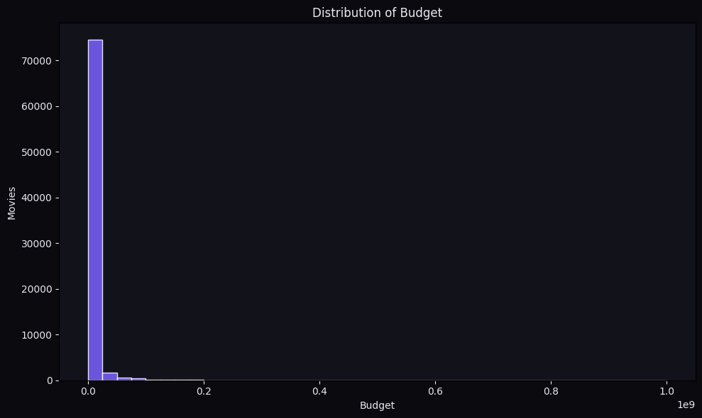

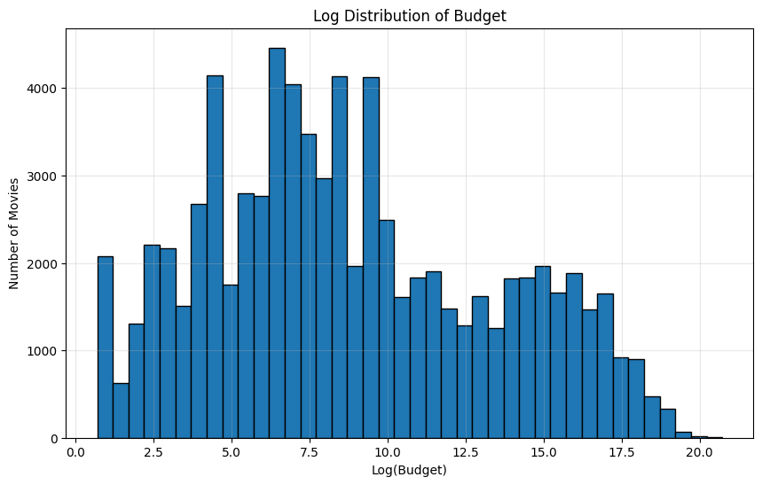

```python
n_data = data['budget'].replace(0, np.nan).dropna()

# Create figure
plt.figure(figsize=(10, 6))

# Plot histogram
plt.hist(
    n_data,
    bins=40,
    color='#7b61ff',
    alpha=0.85,
    edgecolor='white'
)

# Titles and labels
plt.title('Distribution of Budget', fontsize=14, fontweight='bold')
plt.xlabel('Budget')
plt.ylabel('Movies')

# Dark theme styling
plt.gca().set_facecolor('#12121a')
plt.gcf().set_facecolor('#0a0a0f')
plt.gca().tick_params(colors='#e8e8f0')
plt.title('Distribution of Budget', color='#e8e8f0')
plt.xlabel('Budget', color='#e8e8f0')
plt.ylabel('Movies', color='#e8e8f0')

plt.tight_layout()
plt.show()

# Budget & revenue are:
# Extremely right-skewed
# Few blockbuster movies dominate

# Log transformation:

# Reduces skewness
# Makes distribution more normal
# Makes visualization readable

data['budget_log'] = np.log1p(data['budget'])


plt.figure(figsize=(10, 6))

plt.hist(
    data['budget_log'].dropna(),
    bins=40,
    edgecolor='black'
)

plt.title('Log Distribution of Budget')
plt.xlabel('Log(Budget)')
plt.ylabel('Number of Movies')

plt.grid(alpha=0.3)
plt.show()
```

Distribution of Revenue

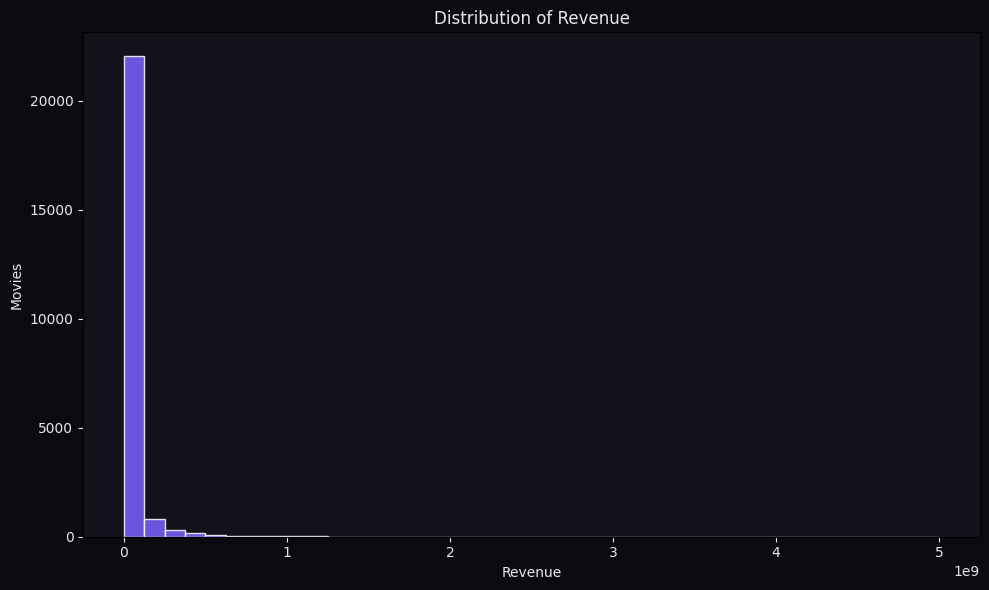

```
c:\Users\Admin\Desktop\TMDB Analysis\env\Lib\site-packages\pandas\core\arraylike.py:402: RuntimeWarning: invalid value encountered in log1p
  result = getattr(ufunc, method)(*inputs, **kwargs)
```

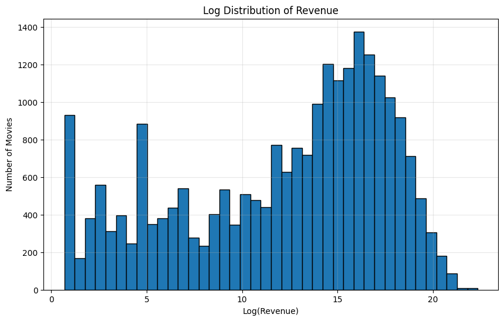

```python
n_data = data['revenue'].replace(0, np.nan).dropna()

# Create figure
plt.figure(figsize=(10, 6))

# Plot histogram
plt.hist(
    n_data,
    bins=40,
    color='#7b61ff',
    alpha=0.85,
    edgecolor='white'
)

# Titles and labels
plt.title('Distribution of Revenue', fontsize=14, fontweight='bold')
plt.xlabel('Revenue')
plt.ylabel('Movies')

# Dark theme styling
plt.gca().set_facecolor('#12121a')
plt.gcf().set_facecolor('#0a0a0f')
plt.gca().tick_params(colors='#e8e8f0')
plt.title('Distribution of Revenue', color='#e8e8f0')
plt.xlabel('Revenue', color='#e8e8f0')
plt.ylabel('Movies', color='#e8e8f0')

plt.tight_layout()
plt.show()

# Budget & revenue are:
# Extremely right-skewed
# Few blockbuster movies dominate

# Log transformation:

# Reduces skewness
# Makes distribution more normal
# Makes visualization readable

data['revenue_log'] = np.log1p(data['revenue'])
plt.figure(figsize=(10, 6))

plt.hist(
    data['revenue_log'].dropna(),
    bins=40,
    edgecolor='black'
)

plt.title('Log Distribution of Revenue')
plt.xlabel('Log(Revenue)')
plt.ylabel('Number of Movies')

plt.grid(alpha=0.3)
plt.show()
```

Distribution of Vote Average

```python
new_data = data['vote_average'].replace(0, np.nan).dropna()

fig = go.Figure()

fig.add_trace(go.Histogram(
    x=new_data,
    nbinsx=40,
    name='Vote Average',
    marker_color='#7b61ff',
    opacity=0.85,
    hovertemplate='Rating: %{x}<br>Count: %{y}<extra></extra>'
))

fig.add_vline(
    x=new_data.mean(),
    line_dash='dash',
    line_color='#f5a623',
    annotation_text=f'Mean: {new_data.mean():.2f}',
    annotation_position='top right'
)

fig.add_vline(
    x=new_data.median(),
    line_dash='dot',
    line_color='#00d4b4',
    annotation_text=f'Median: {new_data.median():.2f}',
    annotation_position='top left'
)

fig.update_layout(
    title='Distribution of Vote Average',
    xaxis_title='Vote Average',
    yaxis_title='Count',
    height=500,
    paper_bgcolor='#0a0a0f',
    plot_bgcolor='#12121a',
    font_color='#e8e8f0',
    bargap=0.05
)

fig.show()
fig.write_image("vote_average_distribution.png")
```

[output not shown]

```python
# Calculate mean and median
mean_vote = data['vote_average'].mean()
median_vote = data['vote_average'].median()

print(f"Mean Vote Average: {mean_vote}")
print(f"Median Vote Average: {median_vote}")
```

```
Mean Vote Average: 6.150100203474459
Median Vote Average: 6.0
```

##### Bivariate & Multivariate Analysis

Movies Status

```python
status_counts = data['status'].value_counts().reset_index()
status_counts.columns = ['status', 'count']
fig = px.pie(
    status_counts, names='status', values='count',
    title='Movie Status Breakdown',
    color_discrete_sequence=px.colors.qualitative.Bold,
    hole=0.4
)
fig.update_traces(textposition='outside', textinfo='percent+label')
fig.show()
```

Movies Languages

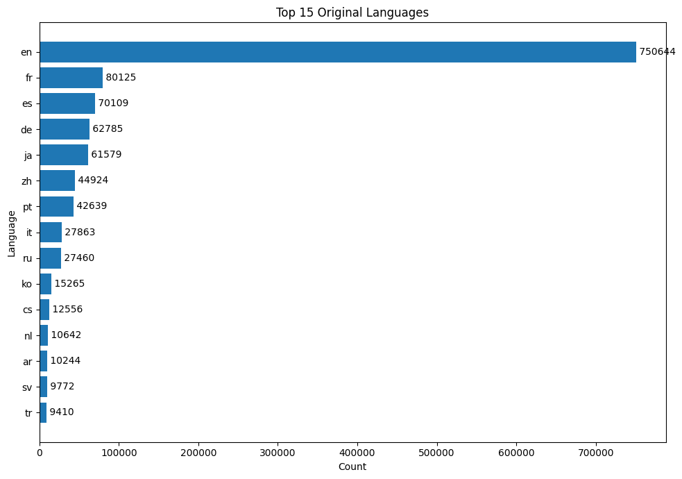

```python
lang_df = data['original_language'].value_counts().head(15).reset_index()
lang_df.columns = ['language', 'count']

lang_df = lang_df.sort_values('count')

plt.figure(figsize=(10, 7))

bars = plt.barh(
    lang_df['language'],
    lang_df['count']
)

plt.title('Top 15 Original Languages')
plt.xlabel('Count')
plt.ylabel('Language')

for index, value in enumerate(lang_df['count']):
    plt.text(value, index, f' {value}', va='center')

plt.tight_layout()
plt.show()
```

Insights by Movie Languages :

The dataset reflects strong representation of English-language films, highlighting Hollywood's global influence.

Normalize Popularity :

Transform popularity data using Min-Max Scaling Normalization because if we scale data between 1-10 then comparision between popularity and vote_average becomes easy and accurate.

```python
pop_min = data['popularity'].min()
pop_max = data['popularity'].max()

print("Popularity Before Scaled")
print(f"Min : {pop_min}, Max : {pop_max}")

data['popularity_scaled'] = 1 + 9 * (
    (data['popularity'] - pop_min) / (pop_max - pop_min)
)

pop_min = data['popularity_scaled'].min()
pop_max = data['popularity_scaled'].max()

print("Popularity After Scaled")
print(f"Min : {pop_min}, Max : {pop_max}")

# Comparison between polularity and vote_average

fig = px.scatter(
    data, x='popularity_scaled', y='vote_average',
    color='vote_count', color_continuous_scale='Plasma',
    title='Popularity vs Rating (coloured by vote count)',
    log_x=True
)
fig.show()
```

```
Popularity Before Scaled
Min : 0.0, Max : 2994.357
Popularity After Scaled
Min : 1.0, Max : 10.0
```

Budget vs Profit Comparison

```python
fig = px.scatter(
    data, x='budget', y='profit',
    color='profit', color_continuous_scale='Plasma',
    title='Budget vs Profit (coloured by profit)',
    log_x=True
)
fig.show()
```

##### Text & Categorical Feature Analysis

Top Movie Genres

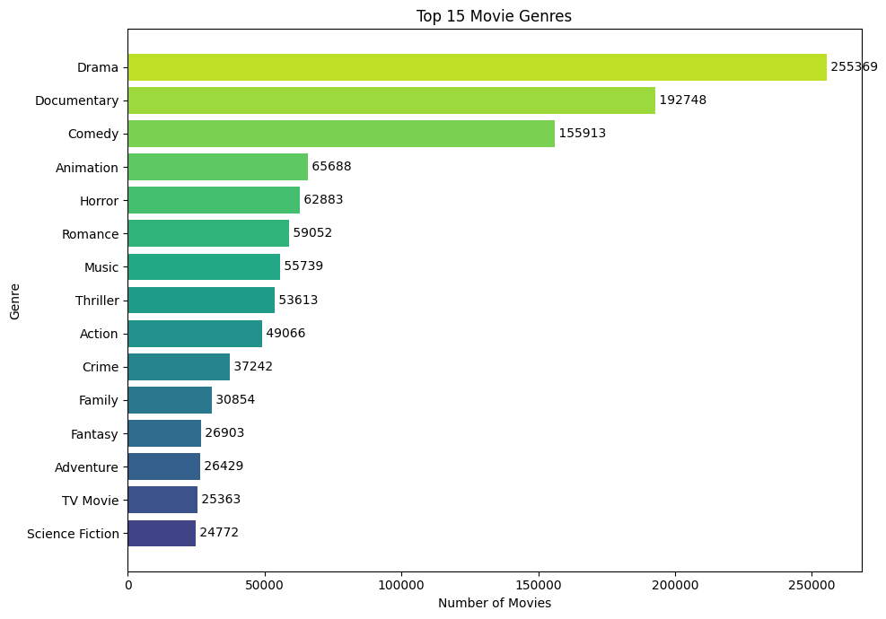

```python
# Genre Frequency

genres_exploded = data.explode('genres')
genre_counts = genres_exploded['genres'].value_counts().head(15)

genre_counts = genre_counts.sort_values()

plt.figure(figsize=(10, 7))

colors = plt.cm.viridis(np.linspace(0.2, 0.9, len(genre_counts)))

bars = plt.barh(
    genre_counts.index,
    genre_counts.values,
    color=colors
)

plt.title('Top 15 Movie Genres')
plt.xlabel('Number of Movies')
plt.ylabel('Genre')

for i, value in enumerate(genre_counts.values):
    plt.text(value, i, f' {value}', va='center')

plt.tight_layout()
plt.show()
```

Insights by Movies Genre :

High-frequency genres such as Drama and Documentary dominate the industry, indicating strong and consistent audience demand.

Top Keywords TreeMap

```python
# Top Keywords Treemap

keywords_explode = data.explode('keywords')
keywords_count = keywords_explode['keywords'].value_counts().head(20)

fig = px.treemap(
    names=keywords_count.index,
    parents=[""] * len(keywords_count),
    values=keywords_count.values,
    title='Top 20 Movie Keywords (Treemap)',
    color_continuous_scale='Teal'
)

fig.update_layout(title_x=0.5)
fig.show()
```

Top Production Companies

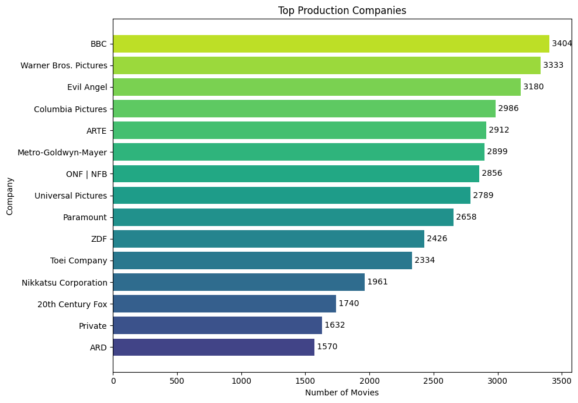

```python
companies_exploded = data.explode('production_companies')
company_counts = companies_exploded['production_companies'].value_counts().head(15)

company_counts = company_counts.sort_values()

plt.figure(figsize=(10, 7))

colors = plt.cm.viridis(np.linspace(0.2, 0.9, len(company_counts)))

bars = plt.barh(
    company_counts.index,
    company_counts.values,
    color=colors
)

plt.title('Top Production Companies')
plt.xlabel('Number of Movies')
plt.ylabel('Company')

for i, value in enumerate(company_counts.values):
    plt.text(value, i, f' {value}', va='center')

plt.tight_layout()
plt.show()
```

Top Companies by Average Revenue

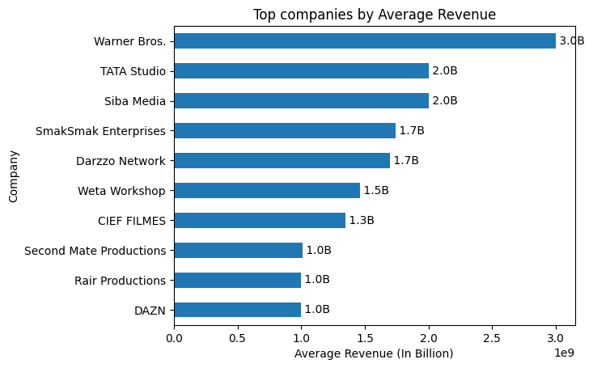

```python
companies = data.explode('production_companies')

company_revenue = companies.groupby('production_companies')['revenue'].mean().sort_values(ascending=False).head(10)

company_revenue = company_revenue.sort_values()

company_revenue.plot(kind='barh')
plt.title('Top companies by Average Revenue')
plt.xlabel('Average Revenue (In Billion)')
plt.ylabel('Company')

for i, value in enumerate(company_revenue.values):
    plt.text(value, i, f' {value/1e9:.1f}B', va='center')

plt.show()
```

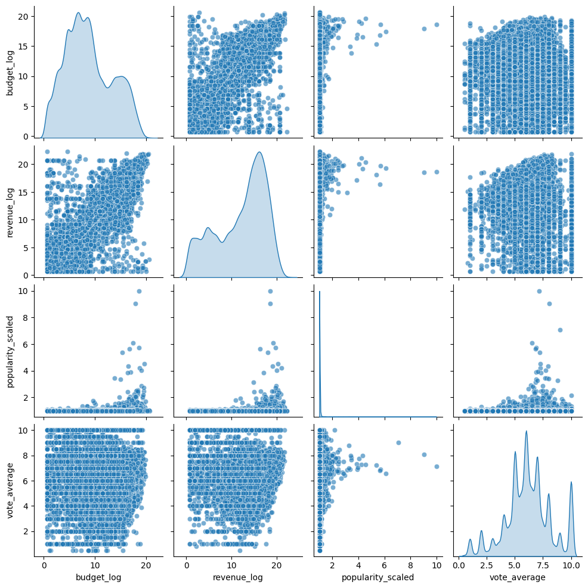

```python
data = data.reset_index(drop=True)

sns.pairplot(
    data[['budget_log','revenue_log','popularity_scaled','vote_average']],
    diag_kind='kde',
    plot_kws={'alpha':0.6},
)

plt.show()
```

Genre Impact on Popularity & Revenue

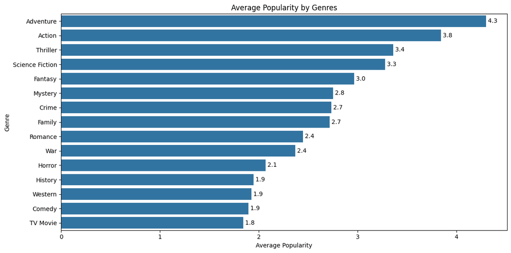

```python
genres_exploded = data.explode('genres')

# Popularity by Genre
genres_popularity = (genres_exploded.groupby('genres')['popularity'].mean().sort_values(ascending=False).head(15))

plt.figure(figsize=(12,6))
sns.barplot(
    x=genres_popularity.values,
    y=genres_popularity.index
)

for i, value in enumerate(genres_popularity.values):
    plt.text(value, i, f' {value:.1f}', va='center')



plt.title('Average Popularity by Genres')
plt.xlabel('Average Popularity')
plt.ylabel('Genre')
plt.tight_layout()
plt.show()
```

Genre Revenue vs Genre Popularity

```python
genres_exploded = data.explode('genres')

genre_summary = (
    genres_exploded
    .groupby('genres')
    .agg({
        'revenue': 'mean',
        'popularity': 'mean',
        'id': 'count'
    })
    .reset_index()
)


genre_summary.columns = ['Genre', 'Avg_Revenue', 'Avg_Popularity', 'Movie_Count']

rev_median = genre_summary['Avg_Revenue'].median()
pop_median = genre_summary['Avg_Popularity'].median()


def classify(row):
    if row['Avg_Revenue'] >= rev_median and row['Avg_Popularity'] >= pop_median:
        return "High Revenue & High Popularity"
    elif row['Avg_Revenue'] >= rev_median and row['Avg_Popularity'] < pop_median:
        return "High Revenue & Low Popularity"
    elif row['Avg_Revenue'] < rev_median and row['Avg_Popularity'] >= pop_median:
        return "Low Revenue & High Popularity"
    else:
        return "Low Revenue & Low Popularity"

genre_summary['Category'] = genre_summary.apply(classify, axis=1)

fig = px.scatter(
    genre_summary,
    x='Avg_Popularity',
    y='Avg_Revenue',
    size='Movie_Count',
    color='Category',
    hover_name='Genre',
    title='Genre Classification: Revenue vs Popularity',
    size_max=60
)

fig.add_hline(y=rev_median, line_dash="dash")
fig.add_vline(x=pop_median, line_dash="dash")

fig.update_layout(
    xaxis_title="Average Popularity",
    yaxis_title="Average Revenue",
    height=650
)

fig.show()
```

Genre by Average Revenue

```python
genre_revenue = genres_exploded.groupby('genres')['revenue'].mean().sort_values(ascending=False).head(15)

fig = px.bar(
    x=genre_revenue.index,
    y=genre_revenue.values,
    title='Average Revenue by Genre',
    labels={'x': 'Genre', 'y': 'Average Revenue'}
)

fig.update_layout(xaxis_tickangle=-45, title_x=0.5)
fig.show()
```

##### Time Series Analysis

Movies Released Per Year

```python
year_count = data['release_year'].value_counts().sort_index()

fig = px.line(
    x = year_count.index,
    y = year_count.values,
    title='Number of Movies Released Per Year',
    labels={'x': 'Year', 'y': 'Number of Movies'}
)

fig.update_layout(title_x = 0.5)
fig.show()
```

[output not shown]

Insights from Movie Release per year :

The film industry has expanded rapidly over the past decades, driven by digital production technologies and global distribution platforms.

Correlation and Statestical Analysis

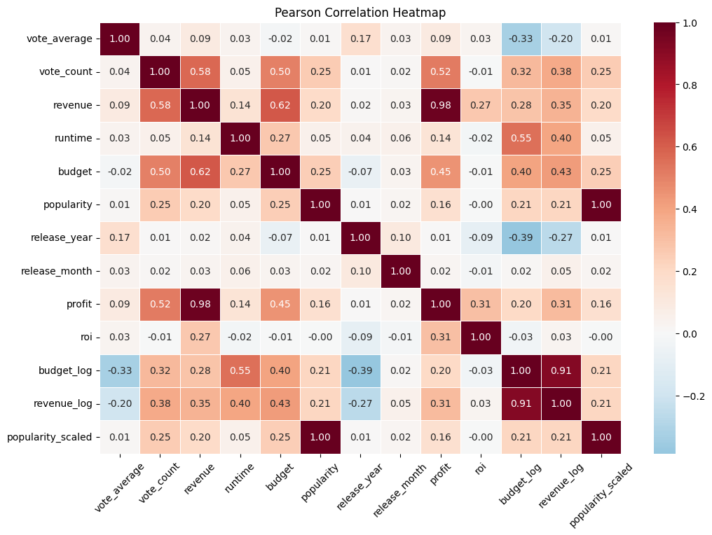

```python
numeric_data = data.select_dtypes(include=np.number)

numeric_data = numeric_data.drop(columns=['id'], errors='ignore')

numeric_data.head()

# Pearson Correlation Matrix

corr_matrix = numeric_data.corr(method='pearson')
corr_matrix.head()

# Correlation Heatmap

plt.figure(figsize=(12,8))

sns.heatmap(
    corr_matrix,
    annot=True,
    fmt='.2f',
    cmap='RdBu_r',
    center=0,
    linewidths=0.5
)

plt.title('Pearson Correlation Heatmap')
plt.xticks(rotation=45)
plt.yticks(rotation=0)

plt.show()
```

Correlation Insights :

Budget ↔ Revenue → Strong positive

Vote Average ↔ Revenue → Weak

Budget & Revenue Insights :

Strong Positive Correlation - Budget shows a strong positive correlation with revenue, indicating that higher production investment often leads to greater box office returns.

Vote Average vs Revenue Insights :

Weak Correlation - Critical or audience ratings do not strongly determine commercial success. Financial performance is influenced more by marketing, franchise value, and distribution scale.

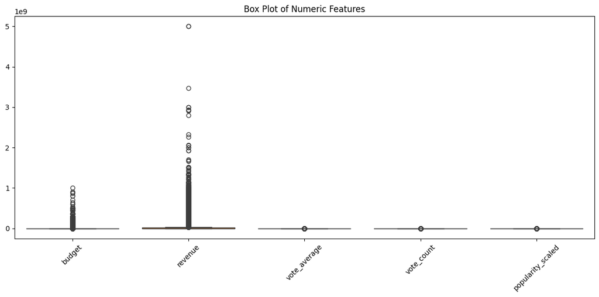

```
c:\Users\Admin\Desktop\TMDB Analysis\env\Lib\site-packages\pandas\core\arraylike.py:402: RuntimeWarning: invalid value encountered in log1p
  result = getattr(ufunc, method)(*inputs, **kwargs)
```

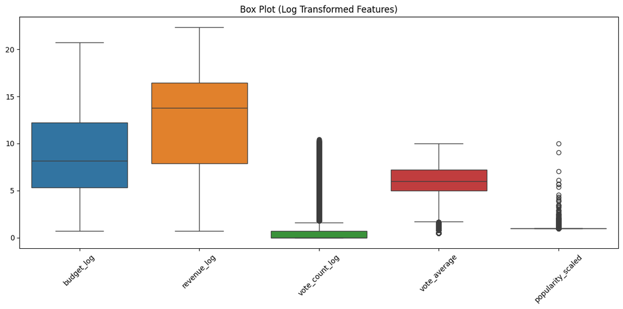

```python
numeric_data = ['budget','revenue','vote_average', 'vote_count', 'popularity_scaled']

plt.figure(figsize=(12, 6))

sns.boxplot(data=data[numeric_data])

plt.title('Box Plot of Numeric Features')
plt.xticks(rotation=45)

plt.tight_layout()
plt.show()

# If i used this data then box plot gives right skewed diagram so i have to transform it using log transformation

data['budget_log'] = np.log1p(data['budget'])
data['revenue_log'] = np.log1p(data['revenue'])
data['vote_count_log'] = np.log1p(data['vote_count'])

log_cols = ['budget_log','revenue_log','vote_count_log',
            'vote_average','popularity_scaled']

plt.figure(figsize=(12, 6))

sns.boxplot(data=data[log_cols])

plt.title('Box Plot (Log Transformed Features)')
plt.xticks(rotation=45)

plt.tight_layout()
plt.show()
```

Insights :

Heavy presence of outliers in revenue & budget so Log transformation improves interpretability of data so use Log Transformation.

The presence of extreme outliers confirms that blockbuster movies significantly distort overall distribution patterns.

Runtime vs Revenue :

```python
data['budget_log'] = np.log1p(data['budget'])
data['revenue_log'] = np.log1p(data['revenue'])

df_fin = data[(data['budget'] > 0) & (data['revenue'] > 0)]

df_fin = df_fin.explode('genres')

fig = px.scatter(
    df_fin,
    x='runtime',
    y='revenue',
    color='genres',
    title='Runtime vs Revenue'
)

fig.show()
fig.write_image("runtime_revenue_by_genre.png")
```

```
c:\Users\Admin\Desktop\TMDB Analysis\env\Lib\site-packages\pandas\core\arraylike.py:402: RuntimeWarning: invalid value encountered in log1p
  result = getattr(ufunc, method)(*inputs, **kwargs)
```

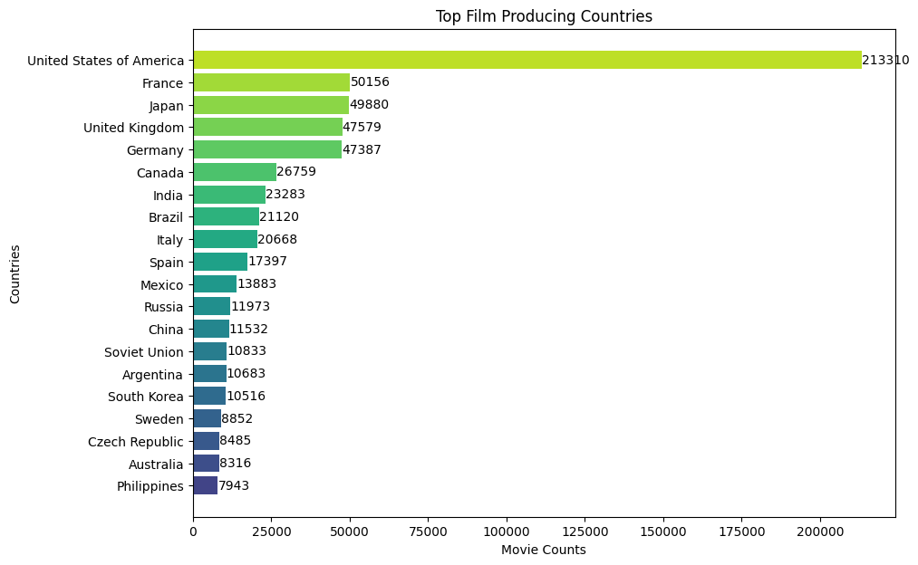

```python
countries = data.explode('production_countries')

country_counts = (
    countries['production_countries'].value_counts().head(20).reset_index()
)

country_counts.columns = ['Country', 'Movie_Count']

country_counts = country_counts.sort_values(by='Movie_Count')

plt.figure(figsize=(10, 7))

colors = plt.cm.viridis(np.linspace(0.2, 0.9, len(country_counts)))

bars = plt.barh(
    country_counts['Country'],
    country_counts['Movie_Count'],
    color=colors
)

plt.title('Top Film Producing Countries')
plt.xlabel('Movie Counts')
plt.ylabel('Countries')

for i, value in enumerate(country_counts.Movie_Count):
    plt.text(value, i, f'{value}', va='center')

plt.show()
```

Production Company Genre Specialization :

Which companies specialize in which genres?

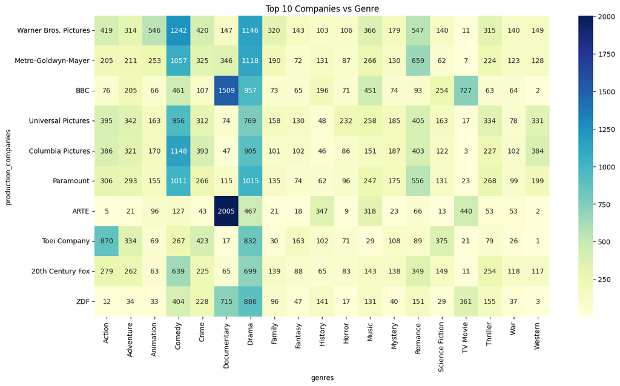

```python
company_genre = (
    data.explode('production_companies').explode('genres').groupby(['production_companies', 'genres']).size().unstack(fill_value=0)
)

top_companies = (company_genre.sum(axis=1).sort_values(ascending=False).head(10).index)

company_genre_top = company_genre.loc[top_companies]

plt.figure(figsize=(15, 8))
sns.heatmap(company_genre_top, cmap='YlGnBu', annot=True, fmt='d')
plt.title("Top 10 Companies vs Genre")
plt.show()
```

Genre wise Top Countries

```python
country_genre = (
    data
    .explode('production_countries')
    .explode('genres')
)

country_genre_count = (
    country_genre.groupby(['genres', 'production_countries']).size().reset_index(name='movie_count')
)

top3_country_per_genre = (
    country_genre_count.sort_values(['genres', 'movie_count'], ascending=[True, False]).groupby('genres').head(3)
)

fig = px.bar(
    top3_country_per_genre,
    x='movie_count',
    y='genres',
    color='production_countries',
    orientation='h',
    title="Top 3 Producing Countries per Genres"
)

fig.show()
fig.write_image("top_producing_countries.png")
```

Distribution of Movie Runtime

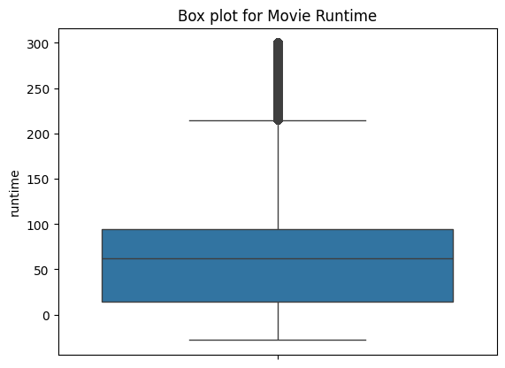

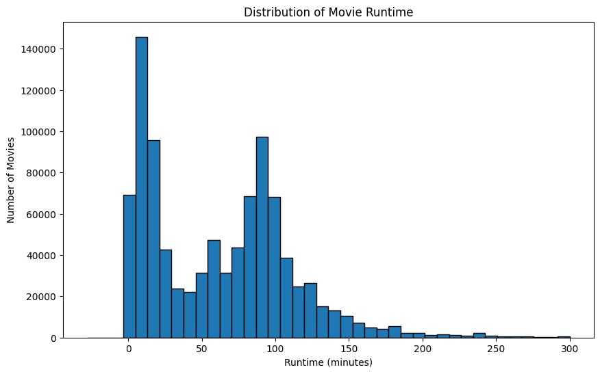

```python
data = data[data['runtime'] <= 300]

sns.boxplot(data['runtime'])
plt.title('Box plot for Movie Runtime')

runtime_data = data['runtime'].dropna()

plt.figure(figsize=(10,6))

plt.hist(runtime_data, bins=40, edgecolor='black')

plt.title("Distribution of Movie Runtime")
plt.xlabel("Runtime (minutes)")
plt.ylabel("Number of Movies")

plt.show()
```

Genre Distribution by Season (Month vs Genre)

```python
genres_exploded = data.explode('genres')

month_genre = (
    genres_exploded
    .groupby(['release_month','genres'])
    .size()
    .reset_index(name='count')
)

pivot = month_genre.pivot(
    index='genres',
    columns='release_month',
    values='count'
)

fig = px.imshow(
    pivot,
    color_continuous_scale='viridis',
    text_auto=True,
    aspect="auto",
    labels=dict(x="Month", y="Genre", color="Movie Count"),
    title="Genre Distribution By Month"
)

fig.update_layout(
    template = 'plotly_white'
)

fig.show()
```

Runtime Distribution By Genre

```python
genre_df = data.copy()

genre_df = genre_df.reset_index(drop=True)

genre_df = genre_df.explode('genres')

genre_df = genre_df.dropna(subset=['runtime', 'genres'])

genre_df['genres'] = genre_df['genres'].astype(str)
genre_df['runtime'] = pd.to_numeric(genre_df['runtime'], errors='coerce')

genre_df = genre_df.drop_duplicates(subset=['genres', 'runtime'])

fig = px.box(
    genre_df,
    x="genres",
    y="runtime",
    color="genres",
    title="Runtime Distribution by Genre"
)

fig.show()
fig.write_image("runtime_distribution_by_genre.png")
```

Franchise Detection Analysis

```python
import re

pattern = r'(?:\b\d+\b|II|III|IV|V|VI|Part|Chapter)'

sequels = data[data['title'].str.contains(pattern, case=False, na=False)].copy()

sequels['franchise'] = (
    sequels['title'].str.replace(pattern, '', regex=True).str.strip()
)

sequels = sequels[(sequels['franchise'] != '') & (sequels['franchise'] != ':') & (sequels['franchise'] != '/')]

franchise_count = (
    sequels['franchise'].value_counts().head(15).reset_index()
)

franchise_count.columns = ['franchise','movie_count']

fig = px.bar(
    franchise_count,
    x='movie_count',
    y='franchise',
    orientation='h',
    title='Top Movie Franchises (Approximation)',
    color='movie_count',
    color_continuous_scale='viridis'
)

fig.update_layout(yaxis={'categoryorder':'total ascending'})
fig.show()
```

Production Company Specialization

```python
company_genre = data.explode('production_companies').explode('genres')

company_genre_count = (
    company_genre.groupby(['production_companies', 'genres']).size().reset_index(name='movie_count')
)

top_companies = company_genre_count.groupby('production_companies')['movie_count'].sum().nlargest(10).index

filtered = company_genre_count[company_genre_count['production_companies'].isin(top_companies)]

pivot = filtered.pivot_table(
    index='production_companies', columns='genres', values='movie_count', fill_value=0
)

fig = px.imshow(
    pivot,
    color_continuous_scale='viridis',
    text_auto=True,
    aspect=True,
    labels=dict(x="Genres", y="Production Company", color="Movie Count"),
    title='Production Company Genre Specialization'
)

fig.show()
```

Keywords trend over time

```python
data['year'] = data['release_date'].dt.year

keywords_df = data.explode('keywords')

top_keywords = keywords_df['keywords'].value_counts().head(10).index

trend_data = keywords_df[keywords_df['keywords'].isin(top_keywords)]

keyword_trend = (trend_data.groupby(['year', 'keywords']).size().reset_index(name='movie_count'))

fig = px.line(
    keyword_trend,
    x='year',
    y='movie_count',
    color='keywords',
    title='Keyword Trend Over Time'
)

fig.show()
```

Movie Production Growth by Country

```python
countries = data.explode('production_countries')

country_year = countries.groupby(['release_year', 'production_countries']).size().reset_index(name='movies')

px.line(
    country_year,
    x='release_year',
    y='movies',
    color='production_countries',
    title='Movie Production by Country Over Time'
)
```